# RetentionAnalytics: Product Retention & Funnel Analysis

Author

Ludovic Njiosseu, MPH (Biostatistics), NYU

Published

November 11, 2026

## Executive summary

This report summarizes the corrected synthetic product analytics workflow. All user and experiment records are simulated. The reported run covers 5,000 users and 92,072 generated session events. The overall signup-to-conversion rate is 12.94%, and overall month-6 retention is 31.26%. The report must be rendered only after running the four scripts in `corrected_r/scripts/` in order.

```r
library(tidyverse)
out <- "corrected_r/outputs"
funnel <- read_csv(file.path(out, "funnel_overall.csv"), show_col_types = FALSE)
retention <- read_csv(file.path(out, "retention_curve_overall.csv"), show_col_types = FALSE)
model <- read_csv(file.path(out, "retention_model_metrics.csv"), show_col_types = FALSE)
ab <- read_csv(file.path(out, "ab_experiment_summary.csv"), show_col_types = FALSE)
ab_tests <- read_csv(file.path(out, "ab_period_tests.csv"), show_col_types = FALSE)

# Preserve the sequential product funnel order in both the table and chart.
funnel <- funnel |>
  mutate(step = factor(step, levels = c("Signup", "Onboarding", "Activation", "Engagement", "Conversion")))
```

## Conversion funnel

The funnel is sequential. Later stages require completion of the preceding stage.

```r
knitr::kable(funnel, digits = 2)
```

| step | users | pct_of_signups | step_conversion_pct | step_dropoff_pct |
| --- | --- | --- | --- | --- |
| Signup | 5000 | 100.00 | 100.00 | 0.00 |
| Onboarding | 3874 | 77.48 | 77.48 | 22.52 |
| Activation | 2407 | 48.14 | 62.13 | 37.87 |
| Engagement | 1387 | 27.74 | 57.62 | 42.38 |
| Conversion | 647 | 12.94 | 46.65 | 53.35 |

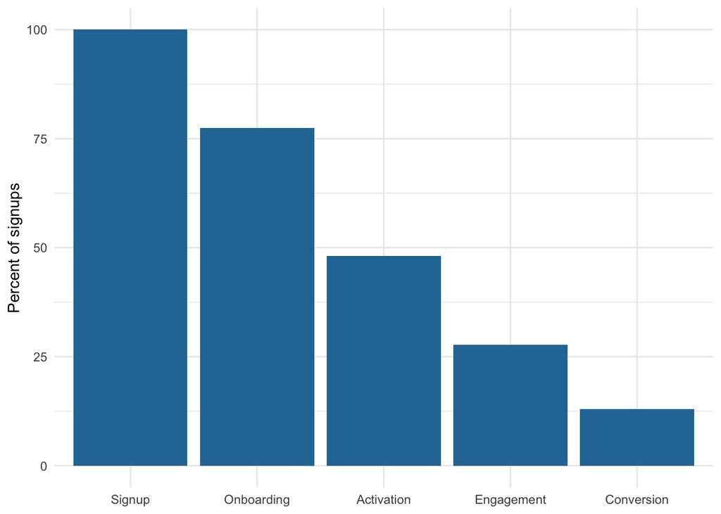

```r
ggplot(funnel, aes(step, pct_of_signups)) +
  geom_col(fill = "#2878a5") +
  labs(x = NULL, y = "Percent of signups") +
  theme_minimal()
```

The activation scenario in `funnel_improvement_projection.csv` holds downstream conditional conversion rates constant. It is a mechanical scenario, not a causal impact estimate.

## Cohort retention

Retention is measured by months since signup. Each month uses the eligible simulated user cohort as its denominator.

```r
knitr::kable(retention, digits = 2)
```

| months_since_signup | retention_rate_pct | active_users | eligible_users |
| --- | --- | --- | --- |
| 1 | 73.36 | 3668 | 5000 |
| 2 | 61.04 | 3052 | 5000 |
| 3 | 49.26 | 2463 | 5000 |
| 4 | 42.08 | 2104 | 5000 |
| 5 | 36.34 | 1817 | 5000 |
| 6 | 31.26 | 1563 | 5000 |
| 7 | 28.44 | 1422 | 5000 |
| 8 | 25.84 | 1292 | 5000 |
| 9 | 23.20 | 1160 | 5000 |
| 10 | 22.26 | 1113 | 5000 |
| 11 | 20.78 | 1039 | 5000 |
| 12 | 19.98 | 999 | 5000 |

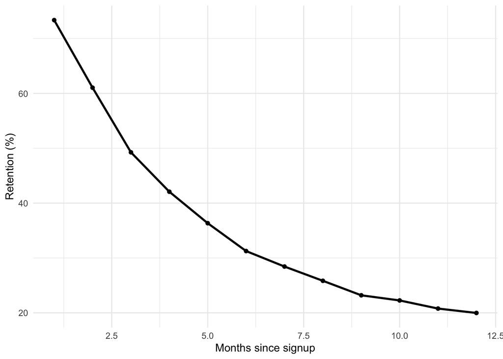

```r
ggplot(retention, aes(months_since_signup, retention_rate_pct)) +
  geom_line(linewidth = 1) + geom_point() +
  labs(x = "Months since signup", y = "Retention (%)") +
  theme_minimal()
```

Month-6 retention by signup cohort is available in `m6_retention_by_cohort.csv`. Segment curves by plan and power-user status are available in `retention_by_plan.csv` and `retention_by_power.csv`.

## Activity and engagement

DAU is calculated over a complete daily calendar, including zero-session days. MAU is the distinct user count within each calendar month. The DAU/MAU ratio is the daily active-user count divided by that month’s MAU, summarized across all calendar days in the month.

```r
dau_mau <- read_csv(file.path(out, "dau_mau_summary.csv"), show_col_types = FALSE)
knitr::kable(dau_mau, digits = 2)
```

| year_month | avg_dau | mau | avg_dau_mau_pct | calendar_days |
| --- | --- | --- | --- | --- |
| 2023-01 | 28.32 | 213 | 13.30 | 31 |
| 2023-02 | 59.21 | 448 | 13.22 | 28 |
| 2023-03 | 89.58 | 659 | 13.59 | 31 |
| 2023-04 | 115.80 | 833 | 13.90 | 30 |
| 2023-05 | 151.29 | 1072 | 14.11 | 31 |
| 2023-06 | 179.13 | 1281 | 13.98 | 30 |
| 2023-07 | 200.77 | 1474 | 13.62 | 31 |
| 2023-08 | 227.68 | 1613 | 14.12 | 31 |
| 2023-09 | 246.73 | 1710 | 14.43 | 30 |
| 2023-10 | 245.35 | 1720 | 14.26 | 31 |
| 2023-11 | 247.73 | 1733 | 14.30 | 30 |
| 2023-12 | 245.58 | 1693 | 14.51 | 31 |
| 2024-01 | 208.39 | 1455 | 14.32 | 31 |
| 2024-02 | 167.76 | 1182 | 14.19 | 29 |
| 2024-03 | 144.84 | 978 | 14.81 | 31 |
| 2024-04 | 125.17 | 867 | 14.44 | 30 |
| 2024-05 | 99.19 | 695 | 14.27 | 31 |
| 2024-06 | 80.77 | 537 | 15.04 | 30 |
| 2024-07 | 58.74 | 395 | 14.87 | 31 |
| 2024-08 | 46.13 | 321 | 14.37 | 31 |
| 2024-09 | 27.57 | 182 | 15.15 | 30 |
| 2024-10 | 15.42 | 102 | 15.12 | 31 |
| 2024-11 | 8.73 | 57 | 15.32 | 30 |

## Predictive modeling

A logistic regression predicts month-6 retention using first-month features. Data are split into training, validation, and held-out test sets. The classification threshold is selected using validation data; final metrics are reported on the held-out test data.

```r
knitr::kable(model, digits = 3)
```

| metric | value |
| --- | --- |
| ROC-AUC | 0.567 |
| Validation-selected threshold | 0.346 |
| Precision | 0.406 |
| Recall | 0.329 |
| Specificity | 0.781 |
| Accuracy | 0.639 |
| Test observations | 1001.000 |

The reported held-out test ROC-AUC is 0.567 (test n = 1,001). At the validation-selected threshold of 0.346, precision is 40.6%, recall is 32.9%, specificity is 78.1%, and accuracy is 63.9%. This is a weak baseline model. Coefficients are associations under the synthetic data-generating process, not causal effects or evidence of real customer behavior.

## Randomized experiment illustration

The A/B experiment is independently simulated and is not drawn from the 5,000-user retention dataset. Its weekly retention probabilities are stipulated inputs. Early-versus-late comparisons illustrate a decaying treatment effect; they do not estimate an empirical novelty effect.

```r
knitr::kable(ab, digits = 2, caption = "Independent simulated experiment by arm")
```

Independent simulated experiment by arm

| arm | n | early_retention_pct | late_retention_pct | week1_pct | week2_pct | week3_pct | week4_pct |
| --- | --- | --- | --- | --- | --- | --- | --- |
| Control | 1251 | 90.57 | 90.73 | 69.62 | 71.86 | 69.86 | 70.02 |
| Treatment | 1251 | 95.68 | 91.93 | 76.42 | 76.26 | 73.22 | 69.38 |

```r
knitr::kable(ab_tests, digits = 3, caption = "Early-versus-later period comparisons")
```

Early-versus-later period comparisons

| period | treatment_minus_control_pp | p_value_one_sided | n_per_arm |
| --- | --- | --- | --- |
| Weeks 1-2 | 5.116 | 0.000 | 1251 |
| Weeks 3-4 | 1.199 | 0.143 | 1251 |

## Limitations

- All records are simulated and should not be presented as observed product data.
- Session generation is conditional on simulated monthly active status, but does not model real-world session timing or product usage complexity.
- The predictive model is a baseline logistic regression and is not a production churn model.
- The A/B experiment is an independent simulation with assumed probabilities, not a live or historical experiment.
- Revenue, acquisition cost, and customer lifetime value are outside the current scope.

## Reproducibility

Run from the repository root:

```r
source("corrected_r/scripts/01_simulate_data.R")
source("corrected_r/scripts/02_funnel_analysis.R")
source("corrected_r/scripts/03_retention_cohorts.R")
source("corrected_r/scripts/04_predictive_model.R")
quarto::quarto_render("retentionanalytics_report.qmd")
```